# Social Network Analysis

**Course:** HUDK 4050, Week 11

**Author:** Zhichun Liu

**Assignment:** ICE8

**Objectives:**

At the end of this ICE, you will be able to:

1. visualize a social network
2. conduct basic network analysis
3. enhance the visualization of your network

## Social Network Analysis

Social network analysis is a method by which one can analyze the connections across individuals or groups or institutions. That is, it allows us to examine how entities are interrelated. In this ICE, we will look at a few important important steps of social network analysis.

First, let’s revisit a couple of important concepts - **Node/Vertex**: Entities in the network, and can hold self-properties (such as weight, size, position and any other attribute) - **Edge/Link/Tie/Arc**: Connections between the nodes, and might hold properties as well (such as weight representing the strength of the connection, direction in case of asymmetric relation or time if applicable) - **Graph/network**: A collection of vertices (or nodes) and edges (or ties), denoted $g(V, E)$, where $V$ is the vertex set and $E$ is the edge set. - **Undirected network**: Undirected networks have edges that do not have a direction. The edges indicate a two-way relationship (i.e., the relationship is symetric), in that each edge can be traversed in both directions. - **Directed network**: Directed networks have edges with direction. The edges indicate a one-way relationship, in that each edge can only be traversed in a single direction. - **Degree**: The number of links to other nodes in the network.

For example, the network below is a directed network with six nodes and six edges. Node B has *one* out-degree (i.e., to C) and *two* in-degree (i.e., from A and D).

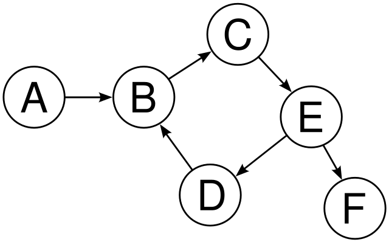

## SNA Data Preparation

There are three ways to store SNA data: (a) node and edge list, (b) adjacency matrix, and (c) adjacency list (see the figure below).

Node and edge list is a most widely used way of storing SNA data. You will have a list of nodes and a list of edge pairs. Notice that you may not need the node list if you don’t have “orphan” nodes – meaning the nodes are not connected to any other nodes (the example in the figure below).

Adjacency matrix is also very commonly use. Instead of having two tables, you just need one big matrix.

Adjacency list is easy to interpret for human eyes but it is less used because it is “untidy”.

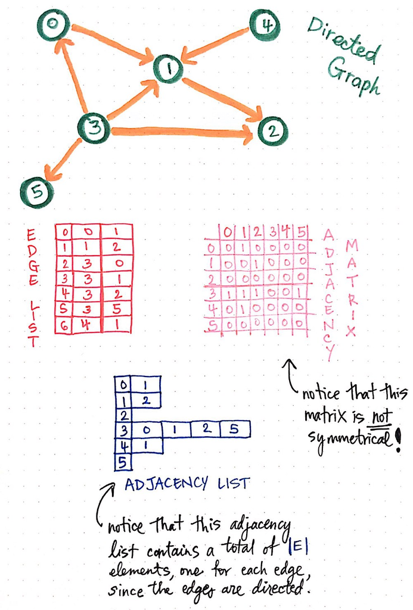